# FigureYa244PCAPlot

**Author(s)**: Jianing Gao  
**Reviewer(s)**: Ying Ge, Hui Huang  
**Date**: 2025-12-03

## 1 Academic Citation

If you use this code in your work or research, we kindly request that you cite our publication:

Xiaofan Lu, et al. (2025). FigureYa: A Standardized Visualization Framework for Enhancing Biomedical Data Interpretation and Research Efficiency. iMetaMed. https://doi.org/10.1002/imm3.70005

## 2 需求描述 Requirement Description

基因聚类，然后在图上标注出来。不用说要跟原文一个数据吧，只要输入数据得出类似的图就行。

Genes are clustered and then annotated on the graph. Needless to say, you need to have the same data as the original text, as long as you enter the data to get a similar graph.

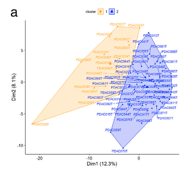

From https://www.sciencedirect.com/science/article/pii/S2352396421003340?via%3Dihub

Fig. 1. Prognostic stratification of PDAC through their GT gene expression profile (a, b) and clinical features of patients with their PDAC molecular profiles (c, d). (a) Biplot of the HCPC analysis result based on RNA-seq data of 74 PDAC and 169 GT genes.

## 3 应用场景 Application Scenarios

先聚类，再用 PCA 可视化聚类结果。聚类算法（如 k-means）在高维空间中计算距离，人类无法直观理解。借用 PCA 将高维空间投影到 2D，让我们看到聚类的空间分布。

用多边形框出每个聚类的边界，视觉上更清晰地展示聚类效果。

- 如果聚类是合理的，在 PCA 图上应该能看到明显分离；
- 如果 PCA 图上混在一起，说明聚类可能过度拟合；
- 用geom_text_repel标注样本名，便于追溯哪个样本不靠谱。

PCA 可以画个小圈圈展示理论分布（置信区间），可参考FigureYa38PCA。

也可以像FigureYa244PCAPlot这样画多边形展示实际分布。灵活运用这样的图来展示正常 PCA/UMAP 结果也完全没问题，直接跳到方法二: ggplot，即可套用。

First cluster, and then use PCA to visualize the clustering results. Clustering algorithms (such as k-means) calculate distances in high-dimensional space, which humans cannot intuitively understand. Using PCA to project high-dimensional space to 2D allows us to see the spatial distribution of clusters.

Use polygons to outline the boundaries of each cluster, providing a clearer visual representation of the clustering effect.

- If clustering is reasonable, you should see clear separation on the PCA plot;
- If samples are mixed together on the PCA plot, it suggests that clustering may be overfitted;
- Use geom_text_repel to label sample names for tracing unreliable samples.

PCA can draw small circles to show theoretical distributions (confidence intervals), refer to FigureYa38PCA.

Alternatively, you can draw polygons like FigureYa244PCAPlot to show actual distributions. This approach can be flexibly applied to display normal PCA/UMAP results as well, simply skip to Method 2: ggplot and apply the template.

## 4 环境设置 Environment settings

```r
source("install_dependencies.R")
```

```
## Starting R package installation...
## ===========================================
##
## Installing CRAN packages...
## Package already installed: tidyverse
## Package already installed: factoextra
##
## ===========================================
## Package installation completed!
```

```r
source("geom_convexhull.R") # from ggConvexHull package
library(tidyverse) # Data manipulation
library(factoextra) # PCA visualization
Sys.setenv(LANGUAGE = "en") #显示英文报错信息 # error messages are displayed in English
options(stringsAsFactors = FALSE) #禁止chr转成factor # chr is not allowed to be converted to factor
```

## 5 输入文件 Input files

easy_input.csv，表达矩阵，每行一个基因，每列一个sample。

easy_input.csv, the expression matrix, one gene per row, one sample per column.

```r
data2 <- read.csv("easy_input.csv", header = T, row.names = 1)
data2[1:2,]
```

```
##                 PDAC020T PDAC019T  PDAC018T  PDAC017T PDAC016T PDAC015T
## ENSG00000176022 8.696719 7.546979 8.8623589 7.7035514  8.45091 9.197024
## ENSG00000158008 0.000000 0.000000 0.5828065 0.5191271  0.00000 0.000000
##                 PDAC014T PDAC013T  PDAC012T PDAC011T  PDAC009T PDAC008T
## ENSG00000176022 7.745252 7.764426 8.4965669 7.204225 8.1506213 8.212629
## ENSG00000158008 0.562378 0.000000 0.9730919 0.000000 0.8267575 0.000000
##                  PDAC007T  PDAC006T  PDAC005T  PDAC004T PDAC003T PDAC001T
## ENSG00000176022 8.3653272 7.9952351 8.4524967 8.5456757 7.385436 8.587829
## ENSG00000158008 0.4760502 0.5777794 0.5299235 0.5168712 3.231115 1.862249
##                 PDAC021T PDAC031T  PDAC030T PDAC029T PDAC028T PDAC027T PDAC026T
## ENSG00000176022 8.272146 9.917087 9.1945540 7.354358 8.441194 8.193225 8.058980
## ENSG00000158008 0.000000 0.000000 0.7081551 1.069634 1.072965 1.051293 1.368179
##                  PDAC025T PDAC024T PDAC023T  PDAC022T  PDAC032T
## ENSG00000176022 8.2723879 8.496848 9.228645 8.7557741 7.8433710
## ENSG00000158008 0.9082814 0.000000 0.000000 0.5601667 0.7110038
```

```r
## kmeans by row. 注意kmean函数是按照行进行聚类的，因此这里需要进行转置，input matrix行为样本，列为特征(基因)
## kmeans by row. Note that the kmean function is clustered by row, so here you need to transpose it, input matrix behavior samples, and list as traits (genes)
k2 <- kmeans(
  x = t(data2), #如果你的数据是行为sample，列为基因，就不需要转置 # If your data is a behavioral sample, listed as a gene, you don't need to transpose it
  centers = 2 # 设置聚类数量 # Set the number of clusters
)

## PCA by row，prcomp函数的input matrix同kmeans
## PCA by row,The input matrix of the prcomp function is the same as that of kmeans
pca <- prcomp(t(data2))
```

## 6 开始画图 Start drawing

### 6.1 方法一: 调用factoextra包 Method 1: Call the factoextra package

```
## Ignoring unknown labels:
## • linetype : "cluster"
```

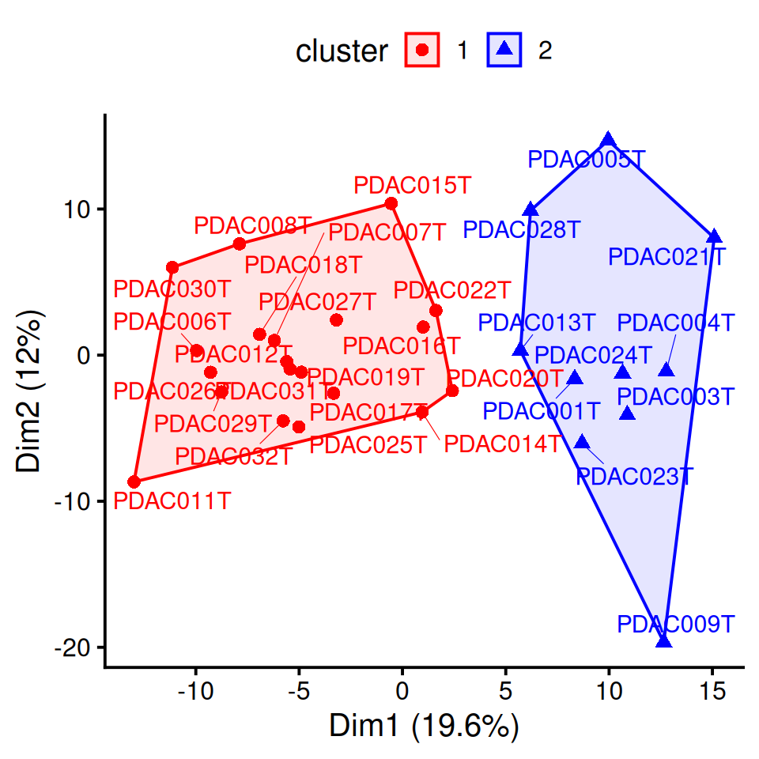

```r
p <- fviz_pca_ind(
  X = pca,
  repel = T,
  geom = c("point", "text"), # 如果不想要文字标记,去掉text即可 # If you don't want the text tag, just remove the text
  habillage = k2$cluster, # 添加分组信息 # Add group information
  legend.title = "cluster", # 图例标题 # Legend title
  mean.point = FALSE, # 是否添加聚类中心 # Whether to add a cluster center
  palette = c("red","blue"), # change color, map to col.ind
  pointsize = 2.5, # 点的大小 # The size of the dot
  addEllipses = TRUE, # 添加外边框 # Add an outer border
  ellipse.type = "convex", # 外边框类型, 凸多边形"convex" # Outer Border Type, Convex Polygon "Convex"
  axes.linetype = "blank", # hide zerolines
  ggtheme = theme_classic(base_size = 15) # ggplot主题 # ggplot theme
)
# remove text legend
p <- p + guides(color = guide_legend(override.aes = aes(label = "")))
# theme
p + theme(
  legend.position = "top",
  plot.title = element_blank(),
  axis.text = element_text(color = "black")
)
```

```r
ggsave("PCA_factoextra.pdf")
```

```
## Ignoring unknown labels:
## • linetype : "cluster"
```

### 6.2 方法二: ggplot Method 2: ggplot

```r
data.use <- as.data.frame(pca$x[, c("PC1", "PC2")])
data.use$cluster <- factor(k2$cluster)
data.use$name <- rownames(data.use)

vars.percent <- pca$sdev^2 / sum(pca$sdev^2) # 计算不同主成分解释的数据方差 # Calculate the variance of the data for different principal component explanations
dims <- c(1,2) # 选择PC1和PC2进行可视化 # Select PC1 and PC2 for visualization
xlab <- paste0("Dim1 (", round(vars.percent[dims[1]]*100, 1), "%)")
ylab <- paste0("Dim2 (", round(vars.percent[dims[2]]*100, 1), "%)")
colors.use <- c("red", "blue")

data.use[1:2,]
```

```
##                PC1       PC2 cluster     name
## PDAC020T  2.414812 -2.431500       1 PDAC020T
## PDAC019T -4.890545 -1.167021       1 PDAC019T
```

画图 Drawing

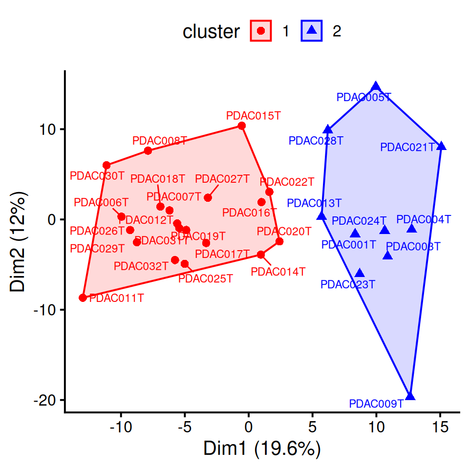

```r
ggplot(data.use, aes(PC1, PC2, shape=cluster, color=cluster)) +
  geom_point(size = 2.5) +
  geom_convexhull(aes(fill=cluster), alpha = 0.15) +
  ggrepel::geom_text_repel(
    aes(label=name),
    size = 3,
    max.iter = 2000, # 如果样本太多，text overlap无法解决，可以增大max.iter参数 # If there are too many samples and the text overlap cannot be solved, you can increase the max.iter parameter
    show.legend = F) +
  scale_color_manual(values = colors.use) +
  scale_fill_manual(values = colors.use) +
  labs(x = xlab, y = ylab) +
  theme_classic(base_size = 15) +
  theme(
    legend.position = "top",
    plot.title = element_blank(),
    axis.text = element_text(color = "black")
  )
```

```r
ggsave("PCA_ggplot2.pdf")
```